# Coursera Practical Machine Learning Course Final Project

# Introduction

This is a submission of the course project for the Practical Machine Learning course on Coursera.org.

# Goal

One thing that people regularly do is quantify how much of a particular activity they do, but they rarely quantify how well they do it. In this project, the goal is to use data from accelerometers on the belt, forearm, arm, and dumbell of 6 participants and predict the manner in which they did the exercise. This is the “classe” variable in the training set. You may use any of the other variables to predict with. We build a prediction model and use it to predict 20 different test cases.

# Background

Using devices such as Jawbone Up, Nike FuelBand, and Fitbit it is now possible to collect a large amount of data about personal activity relatively inexpensively. These type of devices are part of the quantified self movement – a group of enthusiasts who take measurements about themselves regularly to improve their health, to find patterns in their behavior, or because they are tech geeks. One thing that people regularly do is quantify how much of a particular activity they do, but they rarely quantify how well they do it. In this project, your goal will be to use data from accelerometers on the belt, forearm, arm, and dumbell of 6 participants. They were asked to perform barbell lifts correctly and incorrectly in 5 different ways. More information is available from the website here: http://groupware.les.inf.puc-rio.br/har (see the section on the Weight Lifting Exercise Dataset).

The training data for this project are available here:

https://d396qusza40orc.cloudfront.net/predmachlearn/pml-training.csv

The test data are available here:

https://d396qusza40orc.cloudfront.net/predmachlearn/pml-testing.csv

The data for this project come from this source: http://groupware.les.inf.puc-rio.br/har.

# Setup

Working directory is assumed to be the script’s directory. We’re setting the seed and loading required packages.

```r
set.seed(0)

if(!("knitr" %in% rownames(installed.packages()))) {
    install.packages("knitr")
}
library(knitr)

if(!("lattice" %in% rownames(installed.packages()))) {
    install.packages("lattice")
}
library(lattice)

if(!("ggplot2" %in% rownames(installed.packages()))) {
    install.packages("ggplot2")
}
library(ggplot2)

if(!("caret" %in% rownames(installed.packages()))) {
    install.packages("caret")
}
library(caret)

if(!("randomForest" %in% rownames(installed.packages()))) {
    install.packages("randomForest")
}
library(randomForest)
```

# Download source data

We download source data from respective URLs and save files locally. To speed up subsequent script runs and avoid unnecessary downloads, we check if files have been already downloaded.

```r
urlTrainingSource <- "https://d396qusza40orc.cloudfront.net/predmachlearn/pml-training.csv"
trainingSource <- "pml-training.csv"

urlTestingSource <- "https://d396qusza40orc.cloudfront.net/predmachlearn/pml-testing.csv"
testingSource <- "pml-testing.csv"

if(!file.exists(trainingSource)) {
    print(paste("Downloading training source file from", urlTrainingSource))
    download.file(urlTrainingSource, trainingSource, mode = "wb")
} else {
    print("Training source file already downloaded")
}
```

```
## [1] "Downloading training source file from https://d396qusza40orc.cloudfront.net/predmachlearn/pml-training.csv"
```

```r
if(!file.exists(testingSource)) {
    print(paste("Downloading training source file from", urlTestingSource))
    download.file(urlTestingSource, testingSource, mode = "wb")
} else {
    print("Testing source file already downloaded")
}
```

```
## [1] "Downloading training source file from https://d396qusza40orc.cloudfront.net/predmachlearn/pml-testing.csv"
```

# Exploratory analysis and data cleanup

By loading the `trainingSource` and `testingSource` files with `read.csv` and inspecting them with the `summary` command, we determine a number of blank values and values containing `#DIV/0!`. We will consider them `NA` values.

```r
trainingData <- read.csv(trainingSource, na.strings=c("NA", "#DIV/0!", ""))
testingData <- read.csv(testingSource, na.strings=c("NA", "#DIV/0!", ""))
```

We compare column names in our training and testing datasets, to make sure they match. The extra `classe` column in the training dataset is different, but since this is our prediction result variable the columns match appropriately. We may also need to make sure the corresponding values in the two sets are of the same type but will do this step if we run into problems building the prediction model, and for now assume the data types match.

```r
setdiff(colnames(trainingData), colnames(testingData))
```

```
## [1] "classe"
```

We eliminate the first 7 columns since they do not appear to represent information relevant for our prediction.

```r
head(trainingData[, c(1:7)])
```

```
##   X user_name raw_timestamp_part_1 raw_timestamp_part_2   cvtd_timestamp
## 1 1  carlitos           1323084231               788290 05/12/2011 11:23
## 2 2  carlitos           1323084231               808298 05/12/2011 11:23
## 3 3  carlitos           1323084231               820366 05/12/2011 11:23
## 4 4  carlitos           1323084232               120339 05/12/2011 11:23
## 5 5  carlitos           1323084232               196328 05/12/2011 11:23
## 6 6  carlitos           1323084232               304277 05/12/2011 11:23
##   new_window num_window
## 1         no         11
## 2         no         11
## 3         no         11
## 4         no         12
## 5         no         12
## 6         no         12
```

```r
trainingDataOptimized <- trainingData[, -c(1:7)]
```

We also eliminate columns with excessive NA values (only keep columns with 5% or less NAs).

```r
trainingDataOptimized <- trainingDataOptimized[, colMeans(is.na(trainingDataOptimized)) <= .05]
```

The two operations reduce dimensions from 160 to 53.

```r
dim(trainingData)
```

```
## [1] 19622   160
```

```r
dim(trainingDataOptimized)
```

```
## [1] 19622    53
```

Finally, we check for near-zero values for more dimension reduction, but there is nothing to remove.

```r
nzv(trainingDataOptimized, saveMetrics = TRUE)
```

```
##                      freqRatio percentUnique zeroVar   nzv
## roll_belt             1.101904     6.7781062   FALSE FALSE
## pitch_belt            1.036082     9.3772296   FALSE FALSE
## yaw_belt              1.058480     9.9734991   FALSE FALSE
## total_accel_belt      1.063160     0.1477933   FALSE FALSE
## gyros_belt_x          1.058651     0.7134849   FALSE FALSE
## gyros_belt_y          1.144000     0.3516461   FALSE FALSE
## gyros_belt_z          1.066214     0.8612782   FALSE FALSE
## accel_belt_x          1.055412     0.8357966   FALSE FALSE
## accel_belt_y          1.113725     0.7287738   FALSE FALSE
## accel_belt_z          1.078767     1.5237998   FALSE FALSE
## magnet_belt_x         1.090141     1.6664968   FALSE FALSE
## magnet_belt_y         1.099688     1.5187035   FALSE FALSE
## magnet_belt_z         1.006369     2.3290184   FALSE FALSE
## roll_arm             52.338462    13.5256345   FALSE FALSE
## pitch_arm            87.256410    15.7323412   FALSE FALSE
## yaw_arm              33.029126    14.6570176   FALSE FALSE
## total_accel_arm       1.024526     0.3363572   FALSE FALSE
## gyros_arm_x           1.015504     3.2769341   FALSE FALSE
## gyros_arm_y           1.454369     1.9162165   FALSE FALSE
## gyros_arm_z           1.110687     1.2638875   FALSE FALSE
## accel_arm_x           1.017341     3.9598410   FALSE FALSE
## accel_arm_y           1.140187     2.7367241   FALSE FALSE
## accel_arm_z           1.128000     4.0362858   FALSE FALSE
## magnet_arm_x          1.000000     6.8239731   FALSE FALSE
## magnet_arm_y          1.056818     4.4439914   FALSE FALSE
## magnet_arm_z          1.036364     6.4468454   FALSE FALSE
## roll_dumbbell         1.022388    84.2065029   FALSE FALSE
## pitch_dumbbell        2.277372    81.7449801   FALSE FALSE
## yaw_dumbbell          1.132231    83.4828254   FALSE FALSE
## total_accel_dumbbell  1.072634     0.2191418   FALSE FALSE
## gyros_dumbbell_x      1.003268     1.2282132   FALSE FALSE
## gyros_dumbbell_y      1.264957     1.4167771   FALSE FALSE
## gyros_dumbbell_z      1.060100     1.0498420   FALSE FALSE
## accel_dumbbell_x      1.018018     2.1659362   FALSE FALSE
## accel_dumbbell_y      1.053061     2.3748853   FALSE FALSE
## accel_dumbbell_z      1.133333     2.0894914   FALSE FALSE
## magnet_dumbbell_x     1.098266     5.7486495   FALSE FALSE
## magnet_dumbbell_y     1.197740     4.3012945   FALSE FALSE
## magnet_dumbbell_z     1.020833     3.4451126   FALSE FALSE
## roll_forearm         11.589286    11.0895933   FALSE FALSE
## pitch_forearm        65.983051    14.8557741   FALSE FALSE
## yaw_forearm          15.322835    10.1467740   FALSE FALSE
## total_accel_forearm   1.128928     0.3567424   FALSE FALSE
## gyros_forearm_x       1.059273     1.5187035   FALSE FALSE
## gyros_forearm_y       1.036554     3.7763735   FALSE FALSE
## gyros_forearm_z       1.122917     1.5645704   FALSE FALSE
## accel_forearm_x       1.126437     4.0464784   FALSE FALSE
## accel_forearm_y       1.059406     5.1116094   FALSE FALSE
## accel_forearm_z       1.006250     2.9558659   FALSE FALSE
## magnet_forearm_x      1.012346     7.7667924   FALSE FALSE
## magnet_forearm_y      1.246914     9.5403119   FALSE FALSE
## magnet_forearm_z      1.000000     8.5771073   FALSE FALSE
## classe                1.469581     0.0254816   FALSE FALSE
```

# Partitioning

We partition the training dataset into 80% training / 20% validation chunks.

```r
forTrainingIndices <- createDataPartition(y = trainingDataOptimized$classe, p = 0.8, list = FALSE)
trainingDataOptimizedTrainingChunk <- trainingDataOptimized[forTrainingIndices, ]
trainingDataOptimizedValidationChunk <- trainingDataOptimized[-forTrainingIndices, ]

dim(trainingDataOptimizedTrainingChunk)
```

```
## [1] 15699    53
```

```r
dim(trainingDataOptimizedValidationChunk)
```

```
## [1] 3923   53
```

# Choosing and building a model

Since we need to predict categories, it may be reasonable to start with the popular method of Random Forests. First, we check how balanced the training set is, in terms of the count of unique values in the `classe` variable, so that the method does not bias towards relatively large classes. It is reasonably well balanced.

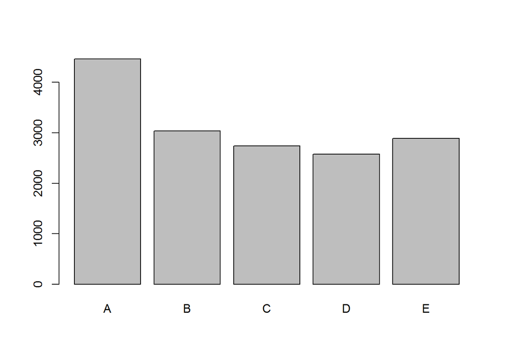

```r
barplot(table(trainingDataOptimizedTrainingChunk$classe))
```

Depending on the out of sample error rate, we may readjust the training controls and attributes, or select a different method all together. For our initial attempt, we train our model with 5-fold cross validation, and no preprocessing. We achieve an excellent estimated error rate of 0.5%, with the largest per-class error of only 1.4%.

```r
fitControl <- trainControl(method = "cv", number = 5)

fitRF <- train(classe ~ ., data = trainingDataOptimizedTrainingChunk,
             method = "rf",
             trControl = fitControl)

fitRF$finalModel
```

```
##
## Call:
##  randomForest(x = x, y = y, mtry = param$mtry)
##                Type of random forest: classification
##                      Number of trees: 500
## No. of variables tried at each split: 2
##
##         OOB estimate of  error rate: 0.5%
## Confusion matrix:
##      A    B    C    D    E class.error
## A 4461    1    1    0    1 0.000672043
## B   10 3023    5    0    0 0.004937459
## C    0   16 2719    3    0 0.006939372
## D    0    0   35 2538    0 0.013602798
## E    0    0    1    5 2880 0.002079002
```

We validate the model against the validation data chunk partition and confirm that the model is an excellent fit, with accuracy over 99% for every class. Because of this result, we are satisfied with selecting this model, and will not attempt to fit any others.

```r
predictionAgainstValidationData <- predict(fitRF,
                                           newdata = trainingDataOptimizedValidationChunk)

confusionMatrix(predictionAgainstValidationData, trainingDataOptimizedValidationChunk$classe)
```

```
## Confusion Matrix and Statistics
##
##           Reference
## Prediction    A    B    C    D    E
##          A 1115    4    0    0    0
##          B    1  754    4    0    0
##          C    0    1  678    9    0
##          D    0    0    2  633    1
##          E    0    0    0    1  720
##
## Overall Statistics
##
##                Accuracy : 0.9941
##                  95% CI : (0.9912, 0.9963)
##     No Information Rate : 0.2845
##     P-Value [Acc > NIR] : < 2.2e-16
##
##                   Kappa : 0.9926
##  Mcnemar's Test P-Value : NA
##
## Statistics by Class:
##
##                      Class: A Class: B Class: C Class: D Class: E
## Sensitivity            0.9991   0.9934   0.9912   0.9844   0.9986
## Specificity            0.9986   0.9984   0.9969   0.9991   0.9997
## Pos Pred Value         0.9964   0.9934   0.9855   0.9953   0.9986
## Neg Pred Value         0.9996   0.9984   0.9981   0.9970   0.9997
## Prevalence             0.2845   0.1935   0.1744   0.1639   0.1838
## Detection Rate         0.2842   0.1922   0.1728   0.1614   0.1835
## Detection Prevalence   0.2852   0.1935   0.1754   0.1621   0.1838
## Balanced Accuracy      0.9988   0.9959   0.9941   0.9918   0.9992
```

# Predicting test data values

The final part of the project is to apply our model to the test set, and submit the results.

```r
submissionPrediction <- predict(fitRF, testingData)
```